# Risk Factor Analysis

## Outcome Variable

**Outcome Variable:** pers_wast

## Predictor Variables

**Intervention Variable:** exclfeed3

**Adjustment Set:**

- arm
- sex
- brthmon
- W_mage
- meducyrs
- feducyrs
- hhwealth_quart
- hfoodsec
- W_mhtcm
- W_mwtkg
- W_mbmi
- vagbrth
- W_gagebrth
- W_birthwt
- W_birthlen
- W_nrooms
- W_nchldlt5
- month
- W_parity
- impfloor
- impsan
- safeh20
- delta_W_mage
- delta_meducyrs
- delta_feducyrs
- delta_hhwealth_quart
- delta_hfoodsec
- delta_W_mhtcm
- delta_W_mwtkg
- delta_W_mbmi
- delta_vagbrth
- delta_W_gagebrth
- delta_W_birthwt
- delta_W_birthlen
- delta_W_nrooms
- delta_W_nchldlt5
- delta_month
- delta_W_parity
- delta_impfloor
- delta_impsan
- delta_safeh20

## Stratifying Variables

The analysis was stratified on these variable(s):

- agecat
- studyid
- country

## Data Summary

| agecat | studyid | country | exclfeed3 | pers_wast | n_cell | n |
| --- | --- | --- | --- | --- | --- | --- |
| 0-24 months | CMC-V-BCS-2002 | INDIA | 1 | 0 | 10 | 10 |
| 0-24 months | CMC-V-BCS-2002 | INDIA | 1 | 1 | 0 | 10 |
| 0-24 months | CMC-V-BCS-2002 | INDIA | 0 | 0 | 0 | 10 |
| 0-24 months | CMC-V-BCS-2002 | INDIA | 0 | 1 | 0 | 10 |
| 0-24 months | EE | PAKISTAN | 1 | 0 | 38 | 39 |
| 0-24 months | EE | PAKISTAN | 1 | 1 | 1 | 39 |
| 0-24 months | EE | PAKISTAN | 0 | 0 | 0 | 39 |
| 0-24 months | EE | PAKISTAN | 0 | 1 | 0 | 39 |
| 0-24 months | GMS-Nepal | NEPAL | 1 | 0 | 326 | 457 |
| 0-24 months | GMS-Nepal | NEPAL | 1 | 1 | 54 | 457 |
| 0-24 months | GMS-Nepal | NEPAL | 0 | 0 | 63 | 457 |
| 0-24 months | GMS-Nepal | NEPAL | 0 | 1 | 14 | 457 |
| 0-24 months | IRC | INDIA | 1 | 0 | 0 | 10 |
| 0-24 months | IRC | INDIA | 1 | 1 | 0 | 10 |
| 0-24 months | IRC | INDIA | 0 | 0 | 9 | 10 |
| 0-24 months | IRC | INDIA | 0 | 1 | 1 | 10 |
| 0-24 months | JiVitA-3 | BANGLADESH | 1 | 0 | 7714 | 8954 |
| 0-24 months | JiVitA-3 | BANGLADESH | 1 | 1 | 470 | 8954 |
| 0-24 months | JiVitA-3 | BANGLADESH | 0 | 0 | 731 | 8954 |
| 0-24 months | JiVitA-3 | BANGLADESH | 0 | 1 | 39 | 8954 |
| 0-24 months | JiVitA-4 | BANGLADESH | 1 | 0 | 136 | 163 |
| 0-24 months | JiVitA-4 | BANGLADESH | 1 | 1 | 10 | 163 |
| 0-24 months | JiVitA-4 | BANGLADESH | 0 | 0 | 16 | 163 |
| 0-24 months | JiVitA-4 | BANGLADESH | 0 | 1 | 1 | 163 |
| 0-24 months | Keneba | GAMBIA | 1 | 0 | 1645 | 1950 |
| 0-24 months | Keneba | GAMBIA | 1 | 1 | 90 | 1950 |
| 0-24 months | Keneba | GAMBIA | 0 | 0 | 194 | 1950 |
| 0-24 months | Keneba | GAMBIA | 0 | 1 | 21 | 1950 |
| 0-24 months | MAL-ED | BANGLADESH | 1 | 0 | 148 | 240 |
| 0-24 months | MAL-ED | BANGLADESH | 1 | 1 | 8 | 240 |
| 0-24 months | MAL-ED | BANGLADESH | 0 | 0 | 80 | 240 |
| 0-24 months | MAL-ED | BANGLADESH | 0 | 1 | 4 | 240 |
| 0-24 months | MAL-ED | BRAZIL | 1 | 0 | 62 | 195 |
| 0-24 months | MAL-ED | BRAZIL | 1 | 1 | 1 | 195 |
| 0-24 months | MAL-ED | BRAZIL | 0 | 0 | 131 | 195 |
| 0-24 months | MAL-ED | BRAZIL | 0 | 1 | 1 | 195 |
| 0-24 months | MAL-ED | INDIA | 1 | 0 | 104 | 215 |
| 0-24 months | MAL-ED | INDIA | 1 | 1 | 8 | 215 |
| 0-24 months | MAL-ED | INDIA | 0 | 0 | 93 | 215 |
| 0-24 months | MAL-ED | INDIA | 0 | 1 | 10 | 215 |
| 0-24 months | MAL-ED | NEPAL | 1 | 0 | 69 | 228 |
| 0-24 months | MAL-ED | NEPAL | 1 | 1 | 2 | 228 |
| 0-24 months | MAL-ED | NEPAL | 0 | 0 | 155 | 228 |
| 0-24 months | MAL-ED | NEPAL | 0 | 1 | 2 | 228 |
| 0-24 months | MAL-ED | PERU | 1 | 0 | 62 | 281 |
| 0-24 months | MAL-ED | PERU | 1 | 1 | 0 | 281 |
| 0-24 months | MAL-ED | PERU | 0 | 0 | 218 | 281 |
| 0-24 months | MAL-ED | PERU | 0 | 1 | 1 | 281 |
| 0-24 months | MAL-ED | SOUTH AFRICA | 1 | 0 | 24 | 264 |
| 0-24 months | MAL-ED | SOUTH AFRICA | 1 | 1 | 0 | 264 |
| 0-24 months | MAL-ED | SOUTH AFRICA | 0 | 0 | 238 | 264 |
| 0-24 months | MAL-ED | SOUTH AFRICA | 0 | 1 | 2 | 264 |
| 0-24 months | MAL-ED | TANZANIA, UNITED REPUBLIC OF | 1 | 0 | 46 | 218 |
| 0-24 months | MAL-ED | TANZANIA, UNITED REPUBLIC OF | 1 | 1 | 0 | 218 |
| 0-24 months | MAL-ED | TANZANIA, UNITED REPUBLIC OF | 0 | 0 | 172 | 218 |
| 0-24 months | MAL-ED | TANZANIA, UNITED REPUBLIC OF | 0 | 1 | 0 | 218 |
| 0-24 months | PROVIDE | BANGLADESH | 1 | 0 | 443 | 641 |
| 0-24 months | PROVIDE | BANGLADESH | 1 | 1 | 8 | 641 |
| 0-24 months | PROVIDE | BANGLADESH | 0 | 0 | 183 | 641 |
| 0-24 months | PROVIDE | BANGLADESH | 0 | 1 | 7 | 641 |
| 0-24 months | SAS-CompFeed | INDIA | 1 | 0 | 355 | 413 |
| 0-24 months | SAS-CompFeed | INDIA | 1 | 1 | 40 | 413 |
| 0-24 months | SAS-CompFeed | INDIA | 0 | 0 | 16 | 413 |
| 0-24 months | SAS-CompFeed | INDIA | 0 | 1 | 2 | 413 |

The following strata were considered:

- agecat: 0-24 months, studyid: CMC-V-BCS-2002, country: INDIA
- agecat: 0-24 months, studyid: EE, country: PAKISTAN
- agecat: 0-24 months, studyid: GMS-Nepal, country: NEPAL
- agecat: 0-24 months, studyid: IRC, country: INDIA
- agecat: 0-24 months, studyid: JiVitA-3, country: BANGLADESH
- agecat: 0-24 months, studyid: JiVitA-4, country: BANGLADESH
- agecat: 0-24 months, studyid: Keneba, country: GAMBIA
- agecat: 0-24 months, studyid: MAL-ED, country: BANGLADESH
- agecat: 0-24 months, studyid: MAL-ED, country: BRAZIL
- agecat: 0-24 months, studyid: MAL-ED, country: INDIA
- agecat: 0-24 months, studyid: MAL-ED, country: NEPAL
- agecat: 0-24 months, studyid: MAL-ED, country: PERU
- agecat: 0-24 months, studyid: MAL-ED, country: SOUTH AFRICA
- agecat: 0-24 months, studyid: MAL-ED, country: TANZANIA, UNITED REPUBLIC OF
- agecat: 0-24 months, studyid: PROVIDE, country: BANGLADESH
- agecat: 0-24 months, studyid: SAS-CompFeed, country: INDIA

### Dropped Strata

Some strata were dropped due to rare outcomes:

- agecat: 0-24 months, studyid: CMC-V-BCS-2002, country: INDIA
- agecat: 0-24 months, studyid: EE, country: PAKISTAN
- agecat: 0-24 months, studyid: IRC, country: INDIA
- agecat: 0-24 months, studyid: JiVitA-4, country: BANGLADESH
- agecat: 0-24 months, studyid: MAL-ED, country: BANGLADESH
- agecat: 0-24 months, studyid: MAL-ED, country: BRAZIL
- agecat: 0-24 months, studyid: MAL-ED, country: NEPAL
- agecat: 0-24 months, studyid: MAL-ED, country: PERU
- agecat: 0-24 months, studyid: MAL-ED, country: SOUTH AFRICA
- agecat: 0-24 months, studyid: MAL-ED, country: TANZANIA, UNITED REPUBLIC OF
- agecat: 0-24 months, studyid: SAS-CompFeed, country: INDIA

## Methods Detail

We're interested in the causal parameters $E[Y_a]$ for all values of $a \in \mathcal{A}$. These parameters represent the mean outcome if, possibly contrary to fact, we intervened to set all units to have $A=a$. Under the randomization and positivity assumptions, these are identified by the statistical parameters $\psi_a=E_W[E_{Y|A,W}(Y|A=a,W)]$. In addition, we're interested in the mean of $Y$, $E[Y]$ under no intervention (the observed mean). We will estimate these parameters by using SuperLearner to fit the relevant likelihood factors -- $E_{Y|A,W}(Y|A=a,W)$ and $p(A=a|W)$, and then updating our likelihood fit using a joint TMLE.

For unadjusted analyses ($W=\{\}$), initial likelihoods were estimated using Lrnr_glm to estimate the simple $E(Y|A)$ and Lrnr_mean to estimate $p(A)$. For adjusted analyses, a small library containing Lrnr_glmnet, Lrnr_xgboost, and Lrnr_mean was used.

Having estimated these parameters, we will then use the delta method to estimate relative risks and attributable risks relative to a prespecified baseline level of $A$.

# Results Detail

## Results Plots

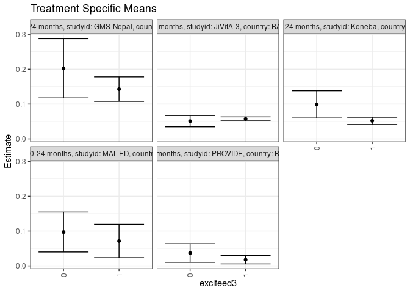

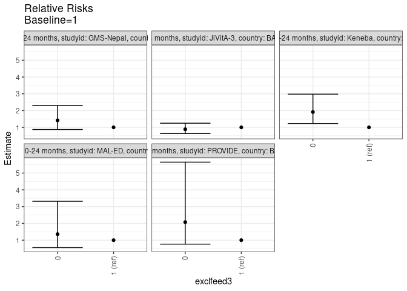

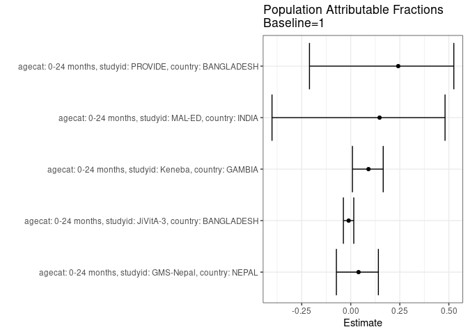

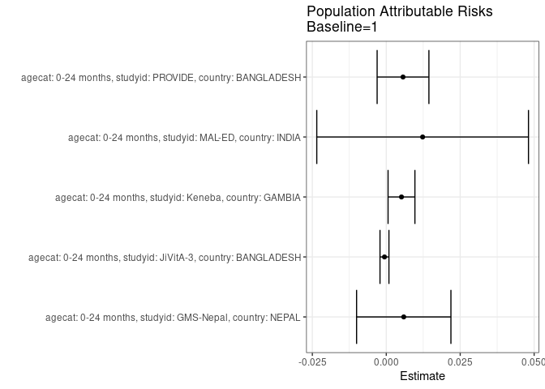

## Results Table

### Parameter: TSM

| agecat | studyid | country | intervention_level | baseline_level | estimate | ci_lower | ci_upper |
| --- | --- | --- | --- | --- | --- | --- | --- |
| 0-24 months | GMS-Nepal | NEPAL | 1 | NA | 0.1428863 | 0.1077240 | 0.1780486 |
| 0-24 months | GMS-Nepal | NEPAL | 0 | NA | 0.2025675 | 0.1176756 | 0.2874594 |
| 0-24 months | JiVitA-3 | BANGLADESH | 1 | NA | 0.0574570 | 0.0516666 | 0.0632475 |
| 0-24 months | JiVitA-3 | BANGLADESH | 0 | NA | 0.0509228 | 0.0346443 | 0.0672013 |
| 0-24 months | Keneba | GAMBIA | 1 | NA | 0.0517791 | 0.0413411 | 0.0622170 |
| 0-24 months | Keneba | GAMBIA | 0 | NA | 0.0990711 | 0.0599745 | 0.1381676 |
| 0-24 months | MAL-ED | INDIA | 1 | NA | 0.0714286 | 0.0236212 | 0.1192360 |
| 0-24 months | MAL-ED | INDIA | 0 | NA | 0.0970874 | 0.0397753 | 0.1543994 |
| 0-24 months | PROVIDE | BANGLADESH | 1 | NA | 0.0177384 | 0.0055465 | 0.0299302 |
| 0-24 months | PROVIDE | BANGLADESH | 0 | NA | 0.0368421 | 0.0100362 | 0.0636481 |

### Parameter: E(Y)

| agecat | studyid | country | intervention_level | baseline_level | estimate | ci_lower | ci_upper |
| --- | --- | --- | --- | --- | --- | --- | --- |
| 0-24 months | GMS-Nepal | NEPAL | NA | NA | 0.1487965 | 0.1161318 | 0.1814612 |
| 0-24 months | JiVitA-3 | BANGLADESH | NA | NA | 0.0568461 | 0.0514610 | 0.0622312 |
| 0-24 months | Keneba | GAMBIA | NA | NA | 0.0569231 | 0.0466368 | 0.0672094 |
| 0-24 months | MAL-ED | INDIA | NA | NA | 0.0837209 | 0.0466125 | 0.1208293 |
| 0-24 months | PROVIDE | BANGLADESH | NA | NA | 0.0234009 | 0.0116889 | 0.0351130 |

### Parameter: RR

| agecat | studyid | country | intervention_level | baseline_level | estimate | ci_lower | ci_upper |
| --- | --- | --- | --- | --- | --- | --- | --- |
| 0-24 months | GMS-Nepal | NEPAL | 1 | 1 | 1.0000000 | 1.0000000 | 1.000000 |
| 0-24 months | GMS-Nepal | NEPAL | 0 | 1 | 1.4176835 | 0.8725097 | 2.303500 |
| 0-24 months | JiVitA-3 | BANGLADESH | 1 | 1 | 1.0000000 | 1.0000000 | 1.000000 |
| 0-24 months | JiVitA-3 | BANGLADESH | 0 | 1 | 0.8862764 | 0.6299206 | 1.246960 |
| 0-24 months | Keneba | GAMBIA | 1 | 1 | 1.0000000 | 1.0000000 | 1.000000 |
| 0-24 months | Keneba | GAMBIA | 0 | 1 | 1.9133412 | 1.2289066 | 2.978969 |
| 0-24 months | MAL-ED | INDIA | 1 | 1 | 1.0000000 | 1.0000000 | 1.000000 |
| 0-24 months | MAL-ED | INDIA | 0 | 1 | 1.3592233 | 0.5568160 | 3.317950 |
| 0-24 months | PROVIDE | BANGLADESH | 1 | 1 | 1.0000000 | 1.0000000 | 1.000000 |
| 0-24 months | PROVIDE | BANGLADESH | 0 | 1 | 2.0769737 | 0.7633930 | 5.650850 |

### Parameter: PAR

| agecat | studyid | country | intervention_level | baseline_level | estimate | ci_lower | ci_upper |
| --- | --- | --- | --- | --- | --- | --- | --- |
| 0-24 months | GMS-Nepal | NEPAL | 1 | NA | 0.0059102 | -0.0100402 | 0.0218607 |
| 0-24 months | JiVitA-3 | BANGLADESH | 1 | NA | -0.0006109 | -0.0021207 | 0.0008988 |
| 0-24 months | Keneba | GAMBIA | 1 | NA | 0.0051440 | 0.0006052 | 0.0096828 |
| 0-24 months | MAL-ED | INDIA | 1 | NA | 0.0122924 | -0.0235037 | 0.0480884 |
| 0-24 months | PROVIDE | BANGLADESH | 1 | NA | 0.0056626 | -0.0030924 | 0.0144175 |

### Parameter: PAF

| agecat | studyid | country | intervention_level | baseline_level | estimate | ci_lower | ci_upper |
| --- | --- | --- | --- | --- | --- | --- | --- |
| 0-24 months | GMS-Nepal | NEPAL | 1 | NA | 0.0397201 | -0.0732890 | 0.1408302 |
| 0-24 months | JiVitA-3 | BANGLADESH | 1 | NA | -0.0107466 | -0.0375323 | 0.0153475 |
| 0-24 months | Keneba | GAMBIA | 1 | NA | 0.0903674 | 0.0085528 | 0.1654307 |
| 0-24 months | MAL-ED | INDIA | 1 | NA | 0.1468254 | -0.4013411 | 0.4805641 |
| 0-24 months | PROVIDE | BANGLADESH | 1 | NA | 0.2419808 | -0.2103743 | 0.5252765 |